# Using LMTP

**Authors**: [Nick Williams](https://nicholastwilliams.com/) and [Ivan Diaz](https://idiaz.xyz/)  
**Updated**: 2020-05-05

This document serves as an introductory guide to using the `lmtp` package. `lmtp` provides an estimation framework for the casual effects of longitudinal modified treatment policies using ensemble machine learning. However, `lmtp` naturally extends to allowing the estimation of traditional causal effects based on binary treatments in both point treatment and time-varying situations.

```r
library(lmtp)
```

## Functions & parameters

> The goal of this section is to introduce the main `lmtp` functions and develop a basic understanding of required and useful function parameters.

### Required vs. optional

The following table describes `lmtp` parameter requirements across the provided estimators:

| Parameter | TMLE | SDR | Substitution | IPW | Required |
| --- | --- | --- | --- | --- | --- |
| data | ✓ | ✓ | ✓ | ✓ | ✓ |
| trt | ✓ | ✓ | ✓ | ✓ | ✓ |
| outcome | ✓ | ✓ | ✓ | ✓ | ✓ |
| nodes | ✓ | ✓ | ✓ | ✓ | ✓ |
| baseline | ✓ | ✓ | ✓ | ✓ |  |
| cens | ✓ | ✓ | ✓ | ✓ |  |
| k | ✓ | ✓ | ✓ | ✓ |  |
| shift | ✓ | ✓ | ✓ | ✓ | ✓ |
| outcome_type | ✓ | ✓ | ✓ |  |  |
| bounds | ✓ | ✓ | ✓ |  |  |
| learners |  |  | ✓ | ✓ |  |
| learners_outcome | ✓ | ✓ |  |  |  |
| learners_trt | ✓ | ✓ |  |  |  |
| folds | ✓ | ✓ | ✓ | ✓ |  |

While many parameters aren’t required, the default options will likely give subpar (or incorrect) results. Special attention should be given to the `k` parameter which is fully described in the Node lists & Markov processes section.

### sl3

`lmtp` relies on the `sl3` package to use ensemble machine learning during estimation procedures. To fully take advantage of the estimators supplied by `lmtp` users must create and then pass to `lmtp` estimators `sl3` learner stacks. `sl3` learner stacks are passed to `lmtp` estimators either through the `learners` argument for `lmtp_sub()` and `lmtp_ipw()` or the `learners_trt` and `learners_outcome` arguments for `lmtp_tmle()` and `lmtp_sdr()`. A full list of supplied `sl3` learners can be found [here](https://tlverse.org/sl3/reference/index.html).

The easiest way to create an `sl3` learner stack is using `sl3::make_learner_stack()`.

```r
library(sl3)

# using learner defaults
lrnrs <- make_learner_stack(Lrnr_mean,
                            Lrnr_glm,
                            Lrnr_ranger)

# specifying learner parameters
lrnrs <-
  make_learner_stack(
    Lrnr_mean,
    Lrnr_glm
    list(Lrnr_ranger,
         num.trees = 1000)
  )
```

The outcome type should guide users on selecting the appropriate learners for a stack when specifying `learners` with `lmtp_sub()` or `learners_outcome` with `lmtp_tmle()` and `lmtp_sdr()`. Regardless of whether an exposure/treatment is continuous or binary, the exposure mechanism is estimated through classification, thus users should only use `sl3` learners that can handle a binary outcome when specifying `learners` with `lmtp_ipw()` or `learners_trt` with `lmtp_tmle()` or `lmtp_sdr()`.

The ensemble meta-learner is always set to `Lrnr_nnls`. If learner stacks aren’t provided, `lmtp` estimators default to an ensemble only made of `Lrnr_mean` and `Lrnr_glm`.

**It is recommended the user reads through the `sl3` [documentation](https://tlverse.org/sl3/index.html) to fully utilize `lmtp`.**

### Node lists & Markov processes

Estimating causal effects in longitudinal settings requires paying special attention to the time-ordering and relationship among covariates. In the `lmtp` framework, there are 5 types of variable nodes: treatment, outcome, baseline, time-varying, and censoring. Treatment and outcome nodes are self-explanatory, baseline nodes are variables that are observed pre-treatment allocation and don’t change (i.e., age at treatment assignment), time-varying nodes are variables that (you guessed it…) change over time, censoring nodes indicate if an observation is observed (or censored) at the next time-point.

How these nodes are specified depends on the specific data generating mechanism and should be pre-specified based on a conceptual model (i.e, a DAG). How these nodes are used by `lmtp` estimators is specified by what we’re calling a node list. The user doesn’t explicitly create the node list themself, instead the user supplies the ingredients and instructions on how to combine. These node list *cooking* instructions are specified through the `k` parameter.

This is best understood through demonstration. The following DAG specifies 1 baseline node, `W`, 3 treatment nodes, `A1`, `A2`, `A3`, 3 time-varying nodes, `L1`, `L2`, `L3`, and an outcome, `Y`.

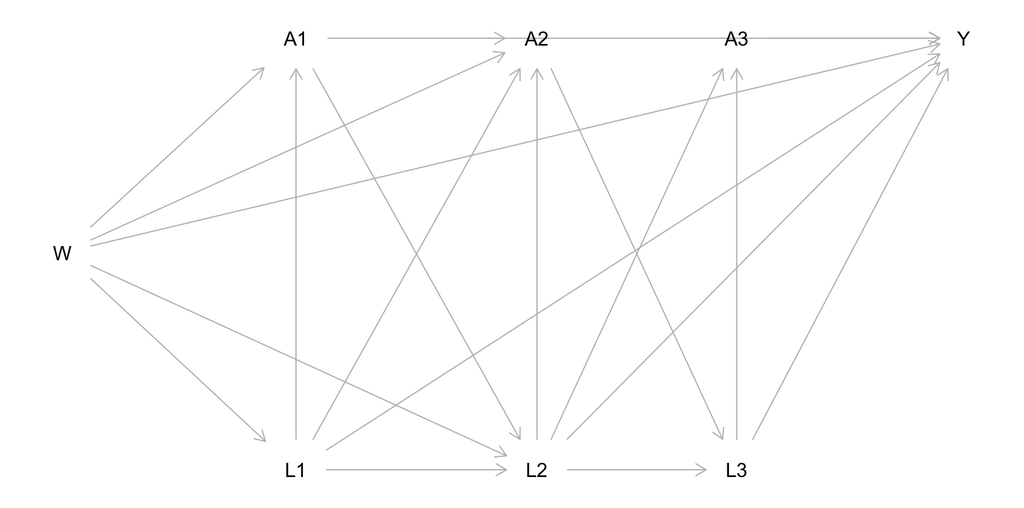

According to the DAG, `Y` is directly affected by all nodes in the model, `k = Inf` would be the correct instructions for creating this node list.

```r
a <- c("A1", "A2", "A3")
nodes <- list(c("W", "L1"),
              c("L2"),
              c("L3"))

# we can make sure our specification is correct by checking create_node_list()
create_node_list(a, nodes, baseline = NULL, k = Inf)
```

```
#> [[1]]
#> [1] "W"  "L1" "A1"
#>
#> [[2]]
#> [1] "W"  "L1" "A1" "L2" "A2"
#>
#> [[3]]
#> [1] "W"  "L1" "A1" "L2" "A2" "L3" "A3"
```

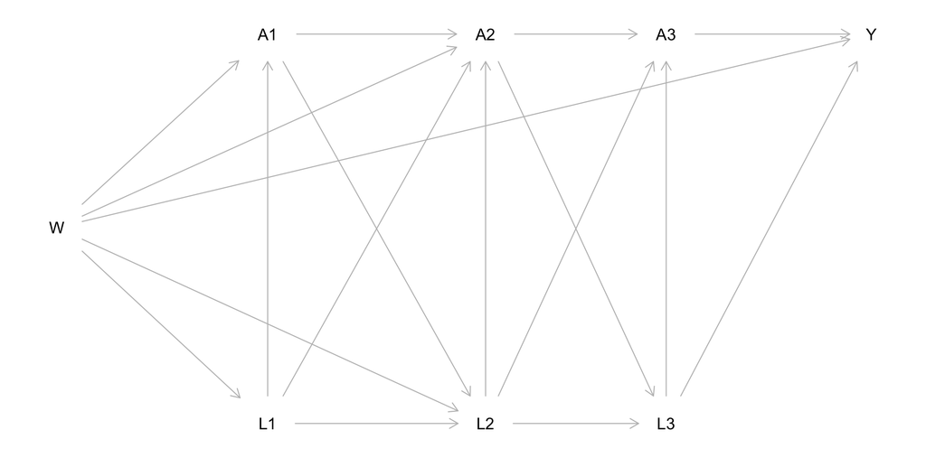

```r
a <- c("A1", "A2", "A3")
baseline <- c("W")
nodes <- list(c("L1"),
              c("L2"),
              c("L3"))

# again checking or specification
create_node_list(a, nodes, baseline = baseline, k = 1)
```

```
#> [[1]]
#> [1] "W"  "L1" "A1"
#>
#> [[2]]
#> [1] "W"  "L1" "A1" "L2" "A2"
#>
#> [[3]]
#> [1] "W"  "L2" "A2" "L3" "A3"
```

## Causal effects

> The goal of this section is to identify how to estimate different causal effects in `lmtp`.

### Modified treatment policies

### Binary treatment

```r
data("iptwExWide", package = "twang")
head(iptwExWide)
```

```
#>      outcome gender age        use0         use1       use2 tx1 tx2 tx3
#> 1 -0.2782802      0  43  1.13496509  0.467482544  0.3174825   1   1   1
#> 2  0.5319329      0  50  1.11193185  0.455965923  0.4059659   1   0   1
#> 3 -0.8173614      1  36 -0.87077763 -0.535388817 -0.5853888   1   0   0
#> 4 -0.1530853      1  63  0.21073159  0.005365793 -0.1446342   1   1   1
#> 5 -0.7344267      0  24  0.06939565 -0.065302176 -0.1153022   1   0   1
#> 6 -0.8519376      1  20 -1.66264885 -0.931324426 -1.0813244   1   1   1
```

```r
a <- c("tx1", "tx2", "tx3")
tv <- list(c("gender", "age", "use0"),
           c("use1"),
           c("use2"))
y <- "outcome"
d <- function(x) 1

lrnrs <- make_learner_stack(Lrnr_glm, Lrnr_mean)

lmtp_tmle(iptwExWide, a, y, tv, shift = d, outcome_type = "continuous",
          learners_outcome = lrnrs, learners_trt = lrnrs)
```

```
#> LMTP Estimator: TMLE
#>    Trt. Policy: (d)
#>
#> Population intervention effect
#>       Estimate: -0.2881
#>     Std. error: 0.0724
#>         95% CI: (-0.43, -0.1462)
```

## Extra features

> The goal of this section is to identify extra features supported by `lmtp` that can improve user experience.

### Tidy results

`lmtp` automatically provides a `tidy` method as described in the [`broom`](https://cran.r-project.org/web/packages/broom/index.html) package:

```r
tidy()
```

### Parallel processing with future

We recommend consulting the `future` [documentation](https://cran.r-project.org/web/packages/future/future.pdf) for more information.

### Progress bars with progressr

In the presence of long computation time, a lack of user feedback can become very frustrating. To address this, `lmtp` supports the use of progress bars during computation through the [`progressr`](https://cran.r-project.org/web/packages/progressr/index.html) package.

```r
library(progressr)

with_progress({
  fit <- lmtp_tmle()
})
```

We recommend consulting the `progressr` [documentation](https://cran.r-project.org/web/packages/progressr/progressr.pdf) for more information.